# Making Outlier Charts

### Install packages

First install the necessary packages using install.packages(“packagename”). [See names in libraries below or copy below] install.packages(“readr”) install.packages(“tidyr”) install.packages(“tidyverse”) install.packages(“ggthemes”) install.packages(“svglite”) install.packages(‘extrafont’)

```r
library(readr)
library(tidyr)
library(extrafont)
library(tidyverse)
library(ggthemes)
library(svglite)
```

### Import fonts

```r
font_import()
```

You can view available fonts and their names by running:

```r
fonts()
```

### Import the Outlier theme

You can import the Outlier styles in one of three ways: (1) Copy the code directly into the script (2) Import the styles from a file on your harddrive (3) Import the styles from GitHub (recommended).

#### 1 - Copy Outlier theme code into your script

```r
theme_outlier <- function () {
  font <- "Roboto Condensed"
  theme_fivethirtyeight(base_size = 12, base_family = font) %+replace%
    theme(
      plot.title = element_text(hjust = 0, vjust = 1.5, lineheight=.8, face="bold", size = 20, family=font, margin = margin(5,0,0,0)),
      plot.subtitle = element_text(hjust = 0, lineheight=.8, size = 15, family=font, margin = margin(0,0,20,0)),
      panel.grid.major.x = element_blank(),
      panel.grid.minor.x = element_blank(),
      panel.grid.major.y = element_line( size=.5, color="gray", linetype = "dotted"),
      axis.line = element_blank(),
      axis.ticks.x = element_line( size = .5, color = "gray", linetype="solid"),
      axis.text = element_text(size = 12),
      axis.text.x = element_text(vjust = 0),
      axis.ticks.length=unit(0.2, "cm"),
      legend.text.align = 0,
      legend.title = element_blank(),
      legend.key = element_blank(),
      legend.text = element_text(family=font, size=10, color="#222222"),
      legend.position = c(0.25, .99),
      legend.direction = "horizontal",
      legend.background = element_rect(fill = "#f0f0f0", color = "lightgray", size = .2, linetype = "solid"),
      legend.key.width = unit(0.5,"cm"),
    )
}
```

#### 2 - Import Outlier styles from a file on your harddrive

```r
source("outlier_theme.R")
```

#### 3 - Import Outlier styles from GitHub (recommended)

```r
source("https://raw.githubusercontent.com/alastairotter/outlier-theme/main/outlier_theme.R")
```

### Making a bar chart

#### Import data from either a local file

```r
vax <- read_csv("~/Documents/R-Projects/vaccinations/data-in/sa-vaccinations.csv")
```

#### Or import from web URL

```r
vax <- read_csv("http://api.mediahack.co.za/adh/sa-vaccinations.csv")
```

#### View data

```r
head(vax)
```

```
## # A tibble: 6 x 3
##   date       vaccinated_daily vaccinated_total
##   <date>                <dbl>            <dbl>
## 1 2021-02-18             2260             2260
## 2 2021-02-19             4264             6524
## 3 2021-02-20             3890            10414
## 4 2021-02-21             4974            15388
## 5 2021-02-22             7671            23059
## 6 2021-02-23             9256            32315
```

```r
summary(vax)
```

```
##       date            vaccinated_daily vaccinated_total
##  Min.   :2021-02-18   Min.   :    0    Min.   :  2260
##  1st Qu.:2021-03-14   1st Qu.:    0    1st Qu.:146096
##  Median :2021-04-07   Median : 4730    Median :281269
##  Mean   :2021-04-07   Mean   : 7775    Mean   :270882
##  3rd Qu.:2021-05-01   3rd Qu.:10619    3rd Qu.:318670
##  Max.   :2021-05-26   Max.   :60999    Max.   :761903
```

#### Set up bar chart

```r
barChart <- ggplot(vax, aes(date, vaccinated_daily)) + # start ggplot and set x and y
  geom_bar(stat = "identity", color="#f0f0f0", fill = "#70ADAD") + # set bar colors
  geom_hline(yintercept = 0, size = .5, color="gray") + # add horizontal line at 0 pioint for baseline
  labs(title="Vaccinations in South Africa",
       subtitle = "Daily vaccinations administered") + # set title and subtitle
  scale_y_continuous(labels = scales::comma) + # use commas as thousand separators
  coord_cartesian( ylim=c(-5,40000), expand = FALSE ) + # sets x-axis labels just below baseline
  theme_outlier() # sets outlier theme as the default style
```

#### Draw barchart plot

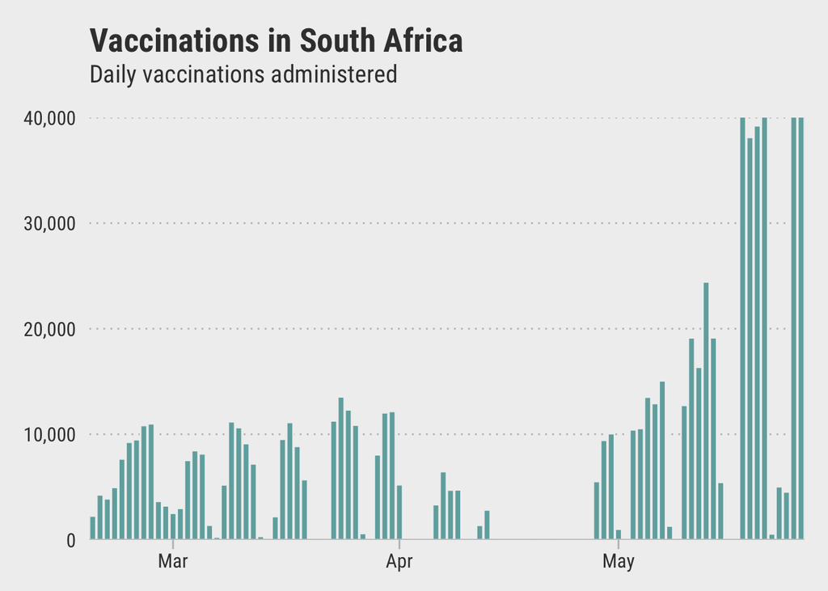

```r
barChart
```

#### Save barchart as an SVG file for Figma, or as a PNG

```r
ggsave(file="examples/barchart.svg", plot=barChart, width=10, height=5) # set file name
ggsave(file="examples/barchart.png", plot=barChart, width=10, height=5) # set file name
```

### Making a multi-line chart

#### Import data from file

```r
vaxrec <- read_csv("~/Documents/R-Projects/vaccinations/data-in/cases-versus-recoveries.csv")
```

#### View data

```r
head(vaxrec)
```

```
## # A tibble: 6 x 3
##   date       cumulative_cases cumulative_recoveries
##   <date>                <dbl>                 <dbl>
## 1 2020-03-05                1                     0
## 2 2020-03-06                1                     0
## 3 2020-03-07                2                     0
## 4 2020-03-08                3                     0
## 5 2020-03-09                7                     0
## 6 2020-03-10                7                     0
```

```r
summary(vaxrec)
```

```
##       date            cumulative_cases  cumulative_recoveries
##  Min.   :2020-03-05   Min.   :      1   Min.   :      0
##  1st Qu.:2020-06-23   1st Qu.: 108952   1st Qu.:  55960
##  Median :2020-10-12   Median : 693359   Median : 624659
##  Mean   :2020-10-12   Mean   : 751218   Mean   : 671937
##  3rd Qu.:2021-01-30   3rd Qu.:1451498   3rd Qu.:1296270
##  Max.   :2021-05-21   Max.   :1628335   Max.   :1534350
```

#### Use tidyverse to combine data fields

This is the preferred method although the same could be achieved with making two geom_line calls.

```r
vaxrecnew <- vaxrec %>%
  select(date, cumulative_cases, cumulative_recoveries) %>%
  gather(key = "variable", value = "value", -date)
```

#### Set up line chart

```r
lineChart <- ggplot(vaxrecnew, aes(x = date, y = value)) +
  geom_line(aes(color = variable)) +
  scale_color_manual(labels = c("Total Cases", "Total Recoveries"), values = c("indianred", "#70ADAD")) +
  scale_linetype_manual(values = c("solid", "dashed")) +
  geom_hline(yintercept = 0, size = .5, color="gray") +
  labs(title="Vaccinations in South Africa",
       subtitle = "Total vaccinations administered") +
  scale_y_continuous(labels = scales::comma) +
  coord_cartesian( ylim=c(-5,max(vaxrecnew$value)* 1.1), expand = FALSE ) +
  theme_outlier() +
  theme(legend.position = c(0.22, .99))
```

#### Set up line chart (annotated)

```r
#start ggplot and set x and y. Each line needs a "+" at the end if there is more code
lineChart <- ggplot(vaxrecnew, aes(x = date, y = value)) +

# use the variable name as the color
geom_line(aes(color = variable)) +

# set the labels and color for each line in the legend
scale_color_manual(labels = c("Total Cases", "Total Recoveries"), values = c("indianred", "#70ADAD")) +

# set the line type for each line
scale_linetype_manual(values = c("solid", "dashed")) +

# add horizontal rule for baseline
geom_hline(yintercept = 0, size = .5, color="gray") +

# sets title and sub-title
labs(title="Vaccinations in South Africa",
    subtitle = "Total vaccinations administered") +

# use commas as thousand separators
scale_y_continuous(labels = scales::comma) +

# sets x axis correctly
coord_cartesian( ylim=c(-5,max(vaxrecnew$value)* 1.1), expand = FALSE ) +

# sets Outlier theme as the default style
theme_outlier() +

# adjust position of legend
theme(legend.position = c(0.22, .99))
```

#### Options for charts

You can override styles in the Outlier theme with some of these below.

```r
#theme(legend.position = c(0.22, .99))  # changes position of legend c(x,y)
#theme(legend.background = element_blank())   removes legend background
#theme(legend.position = "none") removes legend
#theme(legend.position = "bottom")  puts legend below chart (other options: left, right, top)
```

#### Draw line chart

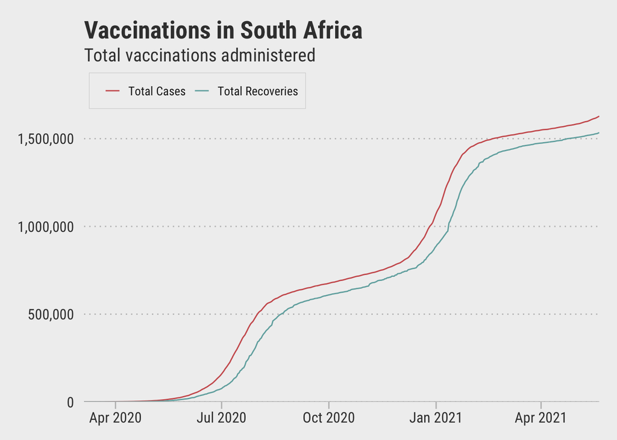

```r
lineChart
```

#### Save line chart as SVG for Figma

```r
ggsave(file="examples/line.svg", plot=lineChart, width=10, height=5)
ggsave(file="examples/line.png", plot=lineChart, width=10, height=5)
```

### Making a stacked bar chart

#### Import data from local csv file

```r
vaxreg <- read_csv("data/registrations.csv")
```

#### View data

```r
head(vaxreg)
```

```
## # A tibble: 6 x 4
##   Province Healthcare SixtyPlus  Total
##   <chr>         <dbl>     <dbl>  <dbl>
## 1 NC            15495     22344  37839
## 2 FS            40379     66534 106913
## 3 MP            39203     77960 117163
## 4 NW            47806    103980 151786
## 5 LP            59214    289175 348389
## 6 EC            97502    294099 391601
```

```r
summary(vaxreg)
```

```
##    Province           Healthcare       SixtyPlus          Total
##  Length:9           Min.   : 15495   Min.   : 22344   Min.   : 37839
##  Class :character   1st Qu.: 40379   1st Qu.: 77960   1st Qu.:117163
##  Mode  :character   Median : 59214   Median :288135   Median :348389
##                     Mean   :106500   Mean   :208892   Mean   :315392
##                     3rd Qu.:164076   3rd Qu.:294099   3rd Qu.:452211
##                     Max.   :296637   Max.   :406720   Max.   :703357
```

#### Format the data

This uses Dplyr to “gather” the data into the columns we need. Before we format the it the data looks like this:

```r
head(vaxreg)
```

```
## # A tibble: 6 x 4
##   Province Healthcare SixtyPlus  Total
##   <chr>         <dbl>     <dbl>  <dbl>
## 1 NC            15495     22344  37839
## 2 FS            40379     66534 106913
## 3 MP            39203     77960 117163
## 4 NW            47806    103980 151786
## 5 LP            59214    289175 348389
## 6 EC            97502    294099 391601
```

Then we format it by selecting a key and value pair and any other columns we want to include in the new data. First, “select” the columns needed, and then “gather” them:

```r
vaxreg <- vaxreg %>%
  select(Province, Healthcare, SixtyPlus, Total) %>%
  gather(key = "variable", value = "value", -Province, -Total)
```

The resulting data looks like:

```r
vaxreg
```

```
## # A tibble: 18 x 4
##    Province  Total variable    value
##    <chr>     <dbl> <chr>       <dbl>
##  1 NC        37839 Healthcare  15495
##  2 FS       106913 Healthcare  40379
##  3 MP       117163 Healthcare  39203
##  4 NW       151786 Healthcare  47806
##  5 LP       348389 Healthcare  59214
##  6 EC       391601 Healthcare  97502
##  7 WC       452211 Healthcare 164076
##  8 KZN      529267 Healthcare 198190
##  9 GP       703357 Healthcare 296637
## 10 NC        37839 SixtyPlus   22344
## 11 FS       106913 SixtyPlus   66534
## 12 MP       117163 SixtyPlus   77960
## 13 NW       151786 SixtyPlus  103980
## 14 LP       348389 SixtyPlus  289175
## 15 EC       391601 SixtyPlus  294099
## 16 WC       452211 SixtyPlus  288135
## 17 KZN      529267 SixtyPlus  331077
## 18 GP       703357 SixtyPlus  406720
```

#### Sort table by Total column

```r
vaxreg <- arrange(vaxreg, desc(-Total))
vaxreg$Province <- factor(vaxreg$Province, levels = unique(vaxreg$Province))
```

#### Create stacked bar chart

```r
stackedBarChart <- ggplot(vaxreg, aes(x = Province, y = value, fill = variable)) +
  geom_bar(stat = "identity", position = "stack") +
  geom_hline(yintercept = 0, size = .5, color="gray") +
  labs(title="Vaccination Resistrations in South Africa",
       subtitle = "Total Registrations") +
  scale_y_continuous(labels = scales::comma) +
  coord_cartesian( ylim=c(-5,1000000), expand = FALSE ) +
  theme_outlier()
```

#### Output stacked bar chart

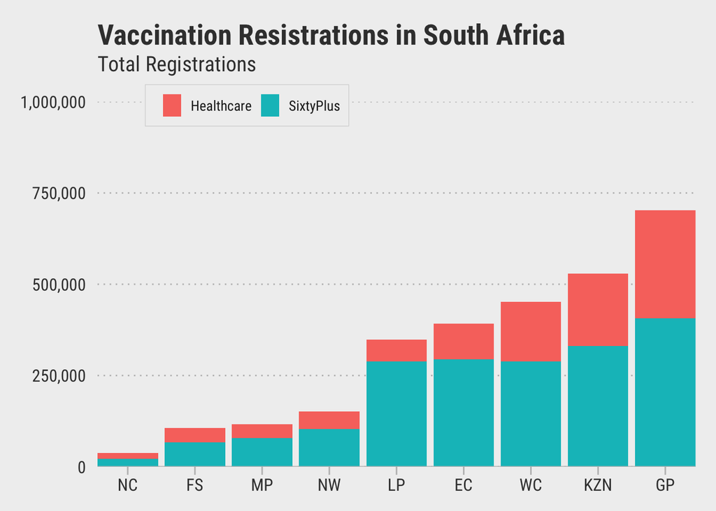

```r
stackedBarChart
```

#### Change the orientation of the bars

You can make a horizontal bar chart using the coord_flip() function and moving the legend using the legend.position function.

```r
stackedBarChart <- stackedBarChart +
  coord_flip() +
  theme(legend.position = c(0.8, 0.1))
```

The result:

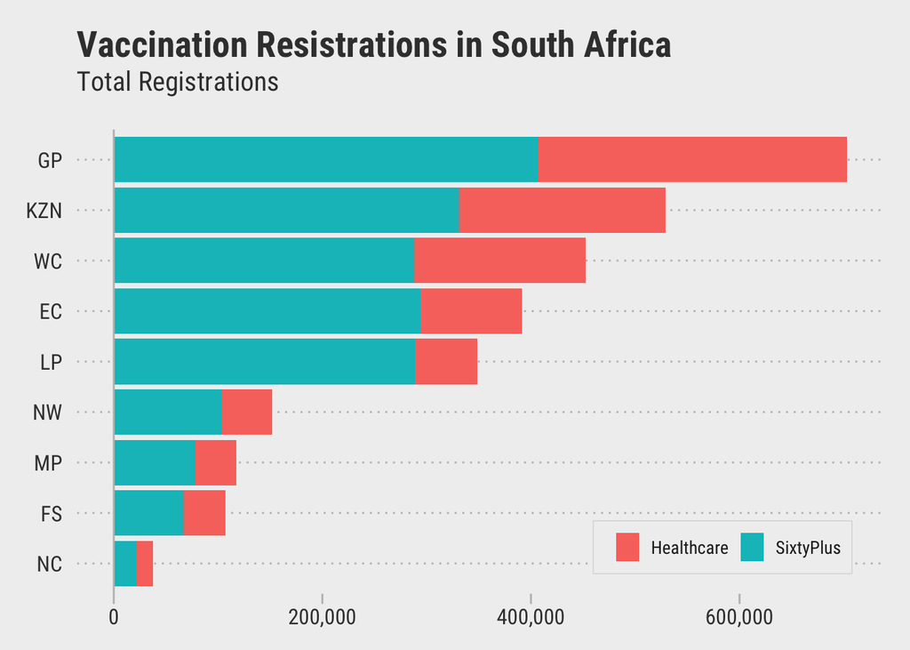

```r
stackedBarChart
```